# Useful inspection plots for the MotU

## d18O

```r
  motu_d18O_weak <- tar_read(motu_temperature) |>
    measurement_filter() |>
    ## tidylog::filter(!is.na(outlier_init), !outlier_init, !is.na(outlier_cycles), !outlier_cycles) |>
    tidylog::filter(!outlier) |>
    pull(d18O_PDB_sd) |>
    median()
```

[output not shown]

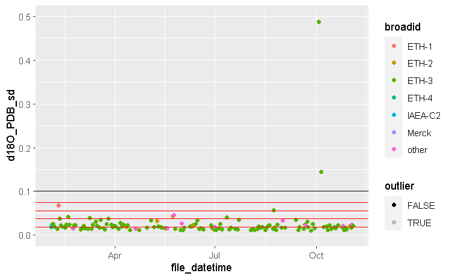

```r
  ## wr_ss |>
  tar_read(motu_temperature) |>
    measurement_filter() |>
    ggplot(aes(x = file_datetime, y = d18O_PDB_sd, colour = broadid, alpha = outlier, label = reason_for_outlier,
               a = Analysis, fi = file_id, s4i = s44_init, r4i = r44_init, p49 = param_49_mean)) +
    geom_point() +
    scale_alpha_manual(values=c("TRUE" = 0.2, "FALSE" = 1)) +
    geom_hline(yintercept = tar_read(motu_temperature) |> distinct(sd_d18O) |> pull(sd_d18O)) +
    geom_hline(yintercept = motu_d18O_weak * c(1, 2, 3, 4), colour = "red") +
    coord_cartesian(ylim = c(0, .5))
```

## D47

```r
  motu_D47_weak <- #wr_ss |>
    tar_read(motu_temperature) |>
    measurement_filter() |>
    ## tidylog::filter(!is.na(outlier_init), !outlier_init, !is.na(outlier_cycles), !outlier_cycles) |>
    tidylog::filter(!outlier) |>
    pull(D47_raw_sd) |>
    median()
```

```
filter: removed 18,645 rows (68%), 8,651 rows remaining
filter: removed 8,435 rows (98%), 216 rows remaining
```

```
filter: removed 18,645 rows (68%), 8,651 rows remaining
distinct: removed 27,295 rows (>99%), one row remaining
```

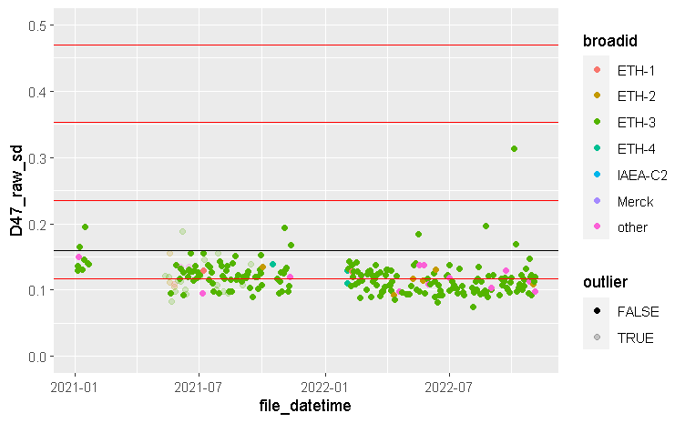

```r
  # wr_ss |>
  tar_read(motu_temperature) |>
    measurement_filter() |>
    ggplot(aes(x = file_datetime, y = D47_raw_sd, colour = broadid, alpha = outlier, label = reason_for_outlier,
               a = Analysis, fi = file_id, s4i = s44_init, r4i = r44_init, p49 = param_49_mean)) +
    geom_point() +
    scale_alpha_manual(values=c("TRUE" = 0.2, "FALSE" = 1)) +
    geom_hline(yintercept = tar_read(motu_temperature) |> distinct(sd_D47) |> pull(sd_D47)) +
    geom_hline(yintercept = motu_D47_weak * c(1, 2, 3, 4), colour = "red") +
    coord_cartesian(ylim = c(0, .5))
```

# Cycles for high-SD samples

*** motu **** attach the cycle data to the final clumped values note that this reads in the latest version of motu_metadata so it should work even if you haven’t updated all targets!

```r
  wr_cyc <- tar_read(motu_raw_deltas) |>
    bind_rows() |>
    #mutate(Analysis = parse_double(Analysis)) |>
    ## select(-scan_files, -scan_duration) |>
    ## tidylog::filter(!outlier) |>
    rename(outlier_cycle_new = outlier) |>
    tidylog::left_join(tar_read(motu_temperature) |>
                       bind_rows()) |>
    tidylog::select(-outlier_manual,
                    -Mineralogy,
                    -starts_with("checked_"),
                    -ends_with("_overwrite")) |>
    tidylog::left_join(tar_read(motu_metadata) |>
                         tidylog::select(file_id,
                                         Analysis,
                                         manual_outlier:checked_comment)) |>
    tidylog::mutate(outlier = outlier |
                      (!is.na(manual_outlier) &
                         manual_outlier))
```

```
           > rows only in x   1,041,899
           > rows only in y  (   26,520)
           > matched rows        32,478
           >                 ===========
           > rows total       1,074,377
select: dropped 10 variables (Mineralogy, outlier_manual, Preparation_overwrite, Identifier 1_overwrite, Identifier 2_overwrite, …)
select: dropped 78 variables (file_root, file_subpath, file_path, file_datetime, file_size, …)
           > rows only in x   1,040,619
           > rows only in y  (   26,520)
           > matched rows        33,758
           >                 ===========
           > rows total       1,074,377
mutate: no changes
```

```r
  ## tidylog::filter(broadid != "other" | (broadid == "other" & Analysis %in% mn$Analysis))

  ## tidylog::filter(!outlier) |>
  ## tidylog::filter(file_id %in% wr_ss$file_id)
```

**** look at D47 cycles for high SD samples

```
filter: removed 1,052,302 rows (98%), 22,075 rows remaining
```

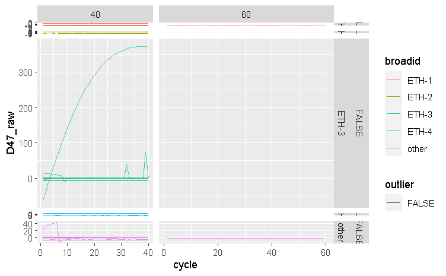

```r
  wr_cyc |>
    tidylog::filter(!outlier,
                    !outlier_cycle_new) |>
    ## tidylog::mutate(SD_bin = cut(D47_raw_sd, seq(0.1, 1, .1))) |>
    ## filter(Analysis %in% c(tar_read(motu_temperature) |>
    ##                        pull(Analysis) |>
    ##                        sample(20))) |>
    ## filter(Analysis %in% c(
    ## ##                        # d13C
    ##                        11517, # also D47
    ## ##                        12283, # also D47
    ##                        13434, 13441, #not that bad
    ##                        13458, # also d18O
    ##                        13485,
    ## ##                        13495,
    ##                        13497,
    ##                        13498,
    ##                        13506,
    ##                        14771,
    ##                        14775
    ## ##                        18807, # also d18O and D47
    ## ##                        # d18O
    ## ##                        12283, # not too bad
    ## ##                        13498,
    ## ##                        19534, # not too bad
    ## ##                        20757,
    ## ##                        # D47
    ## ##                        11425 # not too bad
    ## ##                        # there are a few more that are just small in the youngest part, so up to jan 21
    ##                      )) |>
    ## filter(file_datetime > ymd("2020-01-05") & file_datetime < ymd("2020-04-12")) |> # these have particularly high SD's in d13C, d18O
    ## tidylog::filter(D47_raw_sd > 0.16) |>
    ggplot(aes(x = cycle,
               ## x = s44,
               group = file_id,
               colour = broadid,
               alpha = outlier, a = Analysis #alpha = D47_raw_sd
               )) +
    ## geom_line(aes(y = s44, linetype = "sample")) +
    ## geom_line(aes(y = r44, linetype = "reference")) +
    geom_line(aes(y = #d18O_PDB, #size = s44
                    D47_raw
                    ## d13C_PDB
                ## , alpha = D47_raw_sd > 0.15
                  )) +
    ## scale_size_binned(breaks = seq(5e3, 3e4, 5e3)) +
    ## gghighlight(D47_raw_sd > 0.15)
    ## gghighlight(file_datetime > ymd("2020-01-05") & file_datetime < ymd("2020-04-12")) # these have particularly high SD's in d13C, d18O
    ## geom_line(aes(y = D47_raw)) +
      scale_alpha_manual(values=c("TRUE" = 0.3, "FALSE" = .7)) +
     facet_grid(cols = vars(n_cyc), rows = vars(outlier, broadid),
               scale = "free", space = "free") #+
```

```r
    ## coord_cartesian(ylim = c(-1.2, 0.7))
```

**** look at imbalance between ref gas and sample gas (s44/r44)

```
mutate (grouped): new variable 'dir' (double) with 1,046,354 unique values and 2% NA
filter (grouped): removed 1,052,257 rows (98%), 22,120 rows remaining
filter (grouped): removed 45 rows (<1%), 22,075 rows remaining
filter (grouped): no rows removed
```

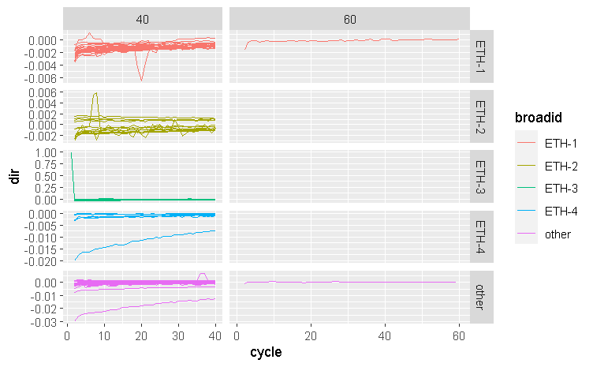

```r
  wr_cyc |>
    # update with newest motu_metadata without re-running all of my code for quicker inspection
    ## tidylog::select(-one_of(colnames(tar_read(motu_metadata))[-c(1:2)])) |>
    ## tidylog::left_join(tar_read(motu_metadata)) |>
    ## tidylog::filter(!manual_outlier) |>
    ## filter(!outlier, !(is.na(reason_for_outlier) | reason_for_outlier == "")) |>
    # calculate the difference between subsequent cycles, within a sample
    group_by(file_id) |>
    tidylog::mutate(dir = s44/r44 - lag(s44/r44)) |>
    ## ggplot(aes(x = dir)) + geom_density()
    # we can filter by this value directly
    ## tidylog::filter(any(dir > -5e-4)) |>
    tidylog::filter(!outlier) |>
    tidylog::filter(!outlier_cycle_new) |>
    tidylog::filter(n_cyc %in% c(40, 60)) |>
    ## tidylog::filter(str_detect(checked_comment, "s44/r44")) |>
    ## tidylog::filter(D47_raw_sd >= 0.16) |>
    mutate(dirsd = sd(dir, na.rm = TRUE)) |>
    ## ggplot(aes(x = dirsd, colour = !outlier)) +
    ## geom_density(n = 4048) +
    ## geom_vline(xintercept = 0.00025) +
    ## coord_cartesian(xlim = c(0, .005))
    # or calculate the standard deviation within the sample and filter by that
    ## tidylog::filter(dirsd > 0.00025) |>
    ## tidylog::filter(broadid == "other") |>
    ggplot(aes(x = cycle,
               group = file_id,
               colour = broadid, #alpha = outlier,
               o = outlier, a = Analysis, ro = reason_for_outlier#alpha = D47_raw_sd
               )) +
    geom_line(aes(#y = s44/r44,
                  group = paste(file_id, Analysis),
                  y = dir
                  ## x = broadid, y = dirsd, group = broadid # for use with geom_violin?
                  ## y = d13C_PDB
                  ## y = d18O_PDB
                  )) +
    ## gghighlight(str_detect(checked_comment, "s44/r44"), keep_scales = TRUE, calculate_per_facet = TRUE) +
    ## gghighlight(dirsd > 0.00025) +
    ## gghighlight(D47_raw_sd >= 0.16) +
    ## facet_wrap(vars(broadid))
    ## scale_alpha_manual(values=c("TRUE" = 0.3, "FALSE" = .7)) +
    # once we've ditched a whole lot of them, we can try this out!
    ## facet_wrap(vars(file_id)) +
    ## labs(title = "These are the measurements with a larger (>0.00025) SD of the difference between cycles' s44/r44")
    ## coord_cartesian(ylim = c(0.84, 1.06)) +
    facet_grid(cols = vars(n_cyc), rows = vars(broadid),
               scale = "free", space = "free_x")
```

**** look at difference in s44/r44

```
mutate (grouped): new variable 'dir' (double) with 1,046,348 unique values and 2% NA
filter (grouped): removed 771 rows (<1%), 1,073,606 rows remaining
filter (grouped): removed 1,051,531 rows (98%), 22,075 rows remaining
```

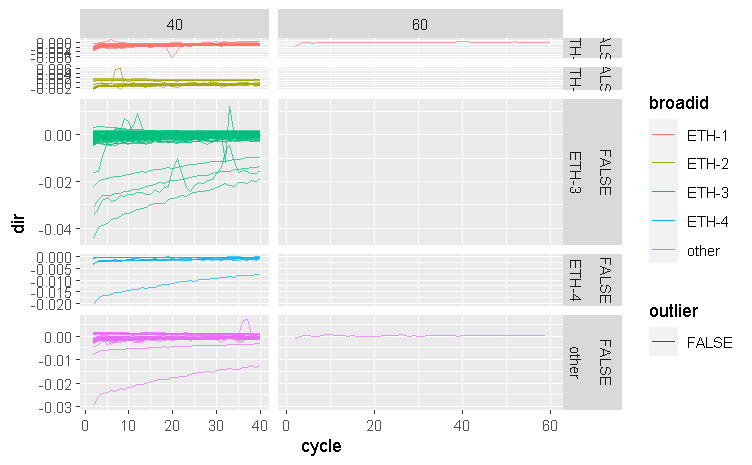

```r
  wr_cyc |>
    group_by(file_id, Analysis) |>
    tidylog::mutate(dir = s44/r44 - lag(s44/r44)) |>
    tidylog::filter(!outlier_cycle_new## , !outlier
                    ) |>
    tidylog::filter(!outlier) |>
    ## tidylog::filter(D47_raw_sd >= 0.16) |>
    mutate(dirsd = sd(dir, na.rm = TRUE)) |>
    ggplot(aes(x = cycle,
               group = file_id,
               colour = broadid,
               alpha = outlier
               ## o = outlier, a = Analysis, ro = reason_for_outlier#alpha = D47_raw_sd
               )) +
    geom_line(aes(#y = s44/r44,
                  group = paste(file_id, Analysis),
                  y = dir
                  ## x = broadid, y = dirsd, group = broadid # for use with geom_violin?
                  ## y = d13C_PDB
                  ## y = d18O_PDB
                  )) +
    scale_alpha_manual(values=c("TRUE" = 0.3, "FALSE" = .7)) +
    facet_grid(cols = vars(n_cyc), rows = vars(outlier, broadid),
               scale = "free", space = "free") #+
```

```r
    # once we've ditched a whole lot of them, we can try this out!
    ## facet_wrap(vars(file_id)) +
    ## labs(title = "These are the measurements with a larger (>0.00025) SD of the difference between cycles' s44/r44")
    ## coord_cartesian(ylim = c(-.005, .002))
```

**** how bad is the trend in D47 vs s44?

```
filter: removed 1,052,302 rows (98%), 22,075 rows remaining
```

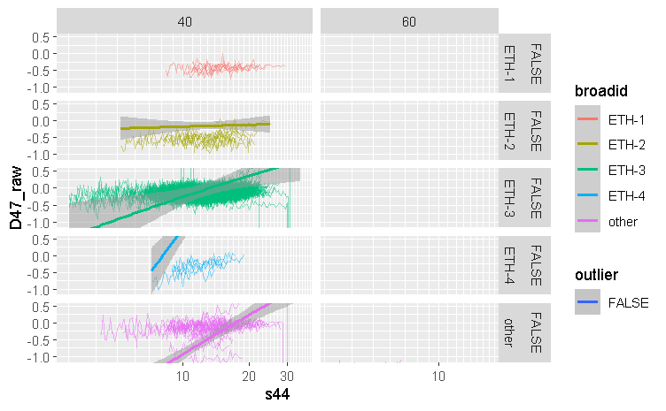

```r
  wr_cyc |>
    tidylog::filter(!outlier,
                    !outlier_cycle_new) |>
    ggplot(aes(x = s44, y = D47_raw, colour = broadid, alpha = outlier)) +
    ## geom_point() +
    geom_path(aes(group = paste(file_id, Analysis))) +
    scale_alpha_manual(values=c("TRUE" = 0.3, "FALSE" = .5)) +
    facet_grid(cols = vars(n_cyc), rows = vars(outlier, broadid),
               scale = "free", space = "free")  +
    coord_cartesian(ylim = c(-1.1, 0.5)) +
    scale_x_log10(breaks = seq(0, 50e3, 1e4), labels = seq(0, 50, 10),
                  minor_breaks = seq(0, 5e4, 1e3)) +
    ## annotation_logticks(sides = "b") +
    geom_smooth(aes(group = broadid), method = "lm", formula = y ~ log10(x))
```

# Offset Correction

*** motu

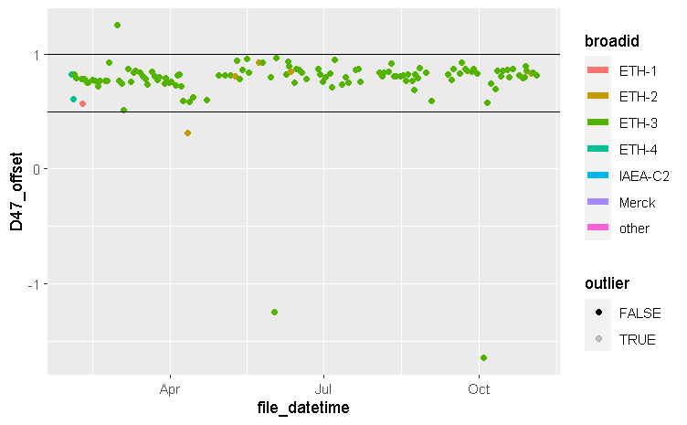

```r
  ## wr_ss |>
  pl_off <- tar_read(motu_temperature) |>
    ## tidylog::filter(broadid != "other" | (broadid == "other" & file_id %in% wr_ss$file_id)) |>
    measurement_filter() |>
    ggplot(aes(x = file_datetime, y = D47_offset,
               colour = broadid, alpha = outlier,
               label = reason_for_outlier, file_id = file_id,
               Analysis = Analysis,
               preparation = preparation,
               reason_for_outlier = reason_for_outlier)) +
    geom_point() +
    # is there a difference in offset between ETH-1 and ETH-2?
    geom_smooth(aes(fill = outlier, linetype = outlier,
                    group = paste(broadid, outlier)),
                formula = y ~ x, method = "loess",
                span = .2, alpha = .2, size = 2, se = F,
                ## , method.args = list(interval = "prediction")  # unfortunately predict.loess doesn't have this option!
                data = tar_read(motu_temperature) |>
                  measurement_filter() |>
                  filter(broadid %in% c("ETH-1", "ETH-2", "ETH-3"))
                ) +
    #geom_smooth(aes(fill = outlier, linetype = outlier, group = outlier),
    #            se = F, formula = y ~ x, method = "loess", span = .2) +
    # This is a clunky way of looking for outliers, it's not based on the 95% prediction interval but on fitting the model to ±0.2‰ in the D47_offset column…
    ## geom_smooth(aes(linetype = outlier, group = outlier), formula = y - .1 ~ x, method = "loess", span = .2, se = F, colour = "red") +
    ## geom_smooth(aes(fill = outlier, linetype = outlier, group = outlier), formula = y + .1 ~ x, method = "loess", span = .2, se = F, colour = "red") +
    sam +
    # this housekeeping makes the outlier loess line invisible
    scale_fill_manual(values=c("TRUE" = NA, "FALSE" = "gray")) +
    scale_linetype_manual(values=c("TRUE" = 0, "FALSE" = 1)) +
    geom_hline(yintercept = ## wr_ss
               tar_read(motu_temperature) |>
                 measurement_filter() |>
                 distinct(off_D47_min, off_D47_max) |> unlist()) #+
    #coord_cartesian(ylim = c(0.45, 1))
  pl_off
```

# ETF

## effect

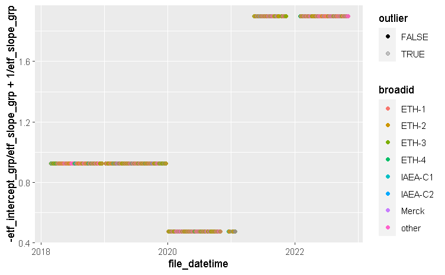

```r
  pl_etf <- tar_read(motu_temperature) |>
    ggplot(aes(x = file_datetime,
               y = - etf_intercept_grp / etf_slope_grp + 1 / etf_slope_grp,
               colour = broadid, alpha = outlier,
               ro = reason_for_outlier, file_id = file_id,
               Analysis = Analysis, preparation = preparation)) +
    geom_point() +
    ## gghighlight(WR) +
    ## coord_cartesian(ylim = c(.68, .75)) +
    sam
  pl_etf
```

## line

*** plot all the ETF slopes/intercepts

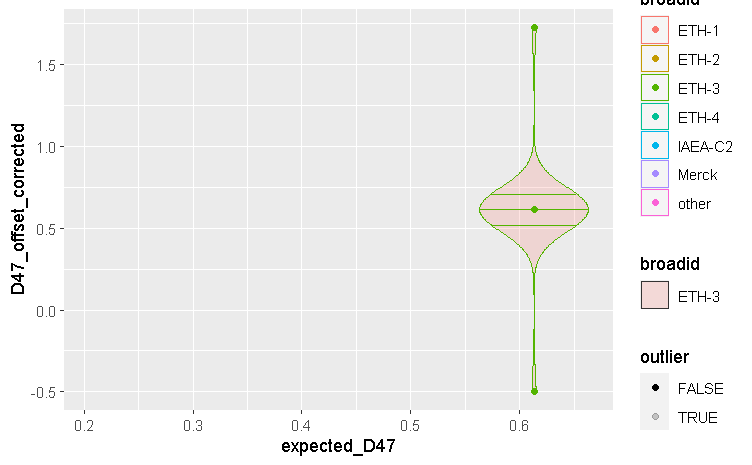

```r
tar_read(motu_temperature) |>
  measurement_filter() |>
    ## filter(file_id %in% wr_ss$file_id) |> # there are some bad runs, but they're not mine so not my problem for now ;-)
  ggplot(aes(x = expected_D47, y = D47_offset_corrected,
             colour = broadid, alpha = outlier,
             fi = file_id, fd = file_datetime,
             ro = reason_for_outlier, p = preparation)) +
  geom_violin(aes(fill = broadid, group = broadid),
              draw_quantiles = c(.25, .5, .75),
              alpha = .2, width = .1,
              data = tar_read(motu_temperature) |>
                measurement_filter() |>
                filter(!outlier)) +
  geom_point() +
  #ggnewscale::new_scale_colour() +
    ## geom_smooth(aes(group = preparation, colour = preparation),
    ##             ## formula = y ~ x - 1, # would this be better if forced through the origin?
    ##             # this would assume that the offset correction completely gets rid of drift
    ##             # RESULT: it's worse, possibly because it gives more weight to ETH-1 and ETH-2?
    ##             method = "lm",
    ##             se = F, fullrange = TRUE,
    ##             data = tar_read(motu_temperature) |>
    ##               filter(!outlier, broadid %in% c(paste0("ETH-", 1:3)))) +
    ## geom_abline(aes(slope = etf_slope, intercept = etf_intercept, colour = preparation), alpha = .1) +
    geom_abline(aes(slope = etf_slope_grp_off,
                    intercept = etf_intercept_grp_off, group = etf_grp),
                alpha = .1) +
    ## geom_abline(slope = 1, intercept = 0) +
    sam #+
```

```r
    #coord_equal(ylim = c(0, .8), xlim = c(0, .9))
```

*** plot all the ETF slopes/intercepts without offset correction

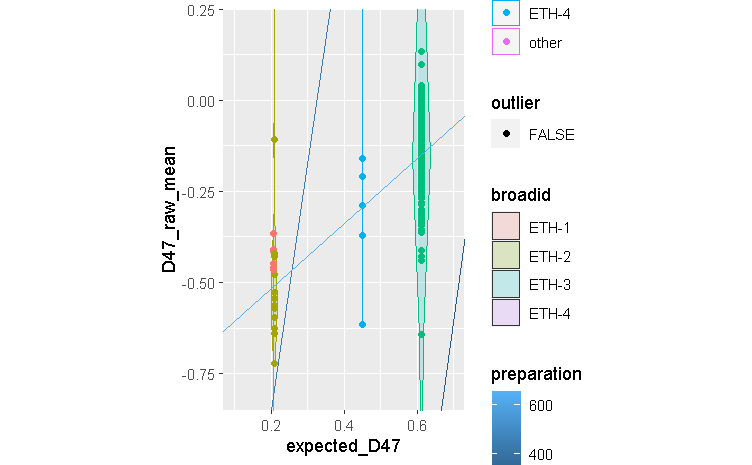

```r
  tar_read(motu_temperature) |>
    filter(!outlier) |>
    ## filter(file_id %in% wr_ss$file_id) |>
    ggplot(aes(x = expected_D47, y = D47_raw_mean,
               colour = broadid, alpha = outlier,
               fi = file_id, fd = file_datetime,
               ro = reason_for_outlier, p = preparation)) +
    geom_violin(aes(fill = broadid, group = broadid),
                alpha = .2, width = .05,
                data = tar_read(motu_temperature) |>
                  filter(!outlier)) +
    geom_point() +
    ## geom_smooth(aes(group = preparation), method = "lm", se = F, data = tar_read(motu_temperature) |> filter(!outlier, broadid %in% c(paste0("ETH-", 1:3)))) +
    ggnewscale::new_scale_colour() +
    geom_abline(aes(slope = etf_slope_grp,
                    intercept = etf_intercept_grp, colour = preparation), alpha = .1) +
    sam +
    coord_equal(ylim = c(-.8, .2), xlim = c(.1, .7)) + theme(legend.pos = "right")
```

# Final Values

## d13C

*** motu

```r
  motu_4sd <-
    tar_read(motu_temperature) |>
    filter(etf_grp %in% tar_read(motu_temperature)$etf_grp[[1]]) |> # filter the standards of interest for Robin van der Ploeg
    group_by(broadid) |>
    tidylog::filter(!outlier) |>
    summarise(d13C = mean(d13C_PDB_mean, na.rm = TRUE),
              d13C_sd = sd(d13C_PDB_mean, na.rm = TRUE),
              d13C_4sd = 4 * d13C_sd,
              criteria_min = d13C - d13C_4sd,
              criteria_max = d13C + d13C_4sd)
```

```
filter: removed 14,476 rows (53%), 12,820 rows remaining
group_by: one grouping variable (broadid)
filter (grouped): removed 12,608 rows (98%), 212 rows remaining
summarise: now 5 rows and 6 columns, ungrouped
```

```r
  library(lubridate)
  ## wr_ss |>
  tar_read(motu_temperature) |>
    filter(etf_grp %in% tar_read(motu_temperature)$etf_grp[[1]]) |> # filter the standards of interest for Robin van der Ploeg
    ggplot(aes(file_id = file_id, Analysis = Analysis,
               x=file_datetime,
               y=d13C_PDB_mean,
               col=broadid,
               label = reason_for_outlier,
               alpha = outlier)) +
    ## geom_pointrange() +
    geom_point() +
    geom_line() +
    geom_hline(aes(yintercept = criteria_min, colour = broadid), data = motu_4sd) +
    geom_hline(aes(yintercept = criteria_max, colour = broadid), data = motu_4sd) +
    geom_hline(aes(yintercept = d13C, colour = broadid), data = motu_4sd) +
    scale_alpha_manual(values=c("TRUE" = 0.2, "FALSE" = 1)) +
    coord_cartesian(ylim = c(-19, 5)) +
    facet_grid(cols = vars(broadid)) + theme(legend.pos = "top")
```

[output not shown]

```
filter: removed 14,476 rows (53%), 12,820 rows remaining
```

## d18O

*** motu

```r
  motu_4sd <- tar_read(motu_temperature) |>
    filter(etf_grp %in% tar_read(motu_temperature)$etf_grp[[1]]) |> # filter the standards of interest for Robin van der Ploeg
    group_by(broadid) |>
    tidylog::filter(!outlier) |>
    summarise(d18O = mean(d18O_PDB_mean, na.rm = TRUE),
              d18O_sd = sd(d18O_PDB_mean, na.rm = TRUE),
              d18O_4sd = 4 * d18O_sd,
              criteria_min = d18O - d18O_4sd,
              criteria_max = d18O + d18O_4sd)
```

```r
  motu_4sd <- tar_read(motu_temperature) |>
    measurement_filter() |>
    group_by(broadid) |>
    tidylog::filter(!outlier) |>
    summarise(D47 = mean(D47_final, na.rm = TRUE),
              D47_sd = sd(D47_final, na.rm = TRUE),
              D47_4sd = 4 * D47_sd,
              criteria_min = D47 - D47_4sd,
              criteria_max = D47 + D47_4sd)
```

```
filter: removed 18,645 rows (68%), 8,651 rows remaining
group_by: one grouping variable (broadid)
filter (grouped): removed 8,435 rows (98%), 216 rows remaining
summarise: now 5 rows and 6 columns, ungrouped
```

```r
  pl_fin <- tar_read(motu_temperature) |>
    measurement_filter() |>
    arrange(file_id, Analysis, file_datetime) |>
    ggplot(aes(file_id = file_id, Analysis = Analysis,
               x=file_datetime,
               # final values with offset correction
               y=D47_final,
               ## ymin= 1 / etf_slope * (D47_raw_lwr + D47_offset_average) - etf_intercept / etf_slope,
               ## ymax= 1 / etf_slope * (D47_raw_upr + D47_offset_average) - etf_intercept / etf_slope,
               # final values without offset correction
               ## y=D47_final_no_offset,
               ## ymin= 1 / etf_slope_raw * (D47_raw_lwr) - etf_intercept_raw / etf_slope_raw,
               ## ymax= 1 / etf_slope_raw * (D47_raw_upr) - etf_intercept_raw / etf_slope_raw,
               col=broadid,
               label = reason_for_outlier,
               alpha = outlier)) +
     ## geom_vline(aes(xintercept = datetime, n = Name, p = `Samples (Name, material, #)`, label = `Comments (issues, observations, maintenance):`),
     ##            data = tar_read(motu_log), alpha = .2, colour = "gray3") +
     ## geom_vline(aes(xintercept = Date, n = Name, p = `Problem (issues, observations):`, a = Actions),
     ##            data = tar_read(motu_maintenance), alpha = .4) +
    ## geom_pointrange() +

    # vertical lines for each scan start
    geom_vline(aes(xintercept = scan_datetime, sg = scan_group, bgg = bg_group),
               colour = "cyan", alpha = .3,
               data = tar_read(motu_temperature) |>
                   measurement_filter() |>
                 distinct(scan_datetime, .keep_all = TRUE)
               ) +

    # segments for each preparation (is nicest for interactive graph)
    geom_segment(aes(x = mn, xend = mx, y = 0.8, yend = 0.8, prep = preparation),
                 alpha = .4, size = 2,
                 inherit.aes = FALSE,
                 data = tar_read(motu_temperature) |>
                   measurement_filter() |>
                   group_by(preparation) |>
                   summarize(mn = min(file_datetime), mx = max(file_datetime))
                 ) +

    geom_point() +
    geom_line(aes(group = broadid)) +
    ## geom_hline(aes(yintercept = criteria_max, colour = broadid), data = motu_4sd) +
    ## geom_hline(aes(yintercept = D47, colour = broadid), data = motu_4sd) +
    ## geom_hline(aes(yintercept = criteria_min, colour = broadid), data = motu_4sd) +
    sam +
    labs(y = "Final Δ47, with offset correction") +
    ## labs(y = "Final Δ47, no offset correction") +
    coord_cartesian(ylim = c(0, .8)) #+
```

```
filter: removed 18,645 rows (68%), 8,651 rows remaining
filter: removed 18,645 rows (68%), 8,651 rows remaining
distinct: removed 8,462 rows (98%), 189 rows remaining
Warning: Ignoring unknown aesthetics: sg and bggfilter: removed 18,645 rows (68%), 8,651 rows remaining
group_by: one grouping variable (preparation)
summarize: now 203 rows and 3 columns, ungrouped
Warning: Using `size` aesthetic for lines was deprecated in ggplot2 3.4.0.
Please use `linewidth` instead.Warning: Ignoring unknown aesthetics: prep
```

[figure not shown]

```r
    ## facet_grid(rows = vars(broadid))
    ## facet_grid(cols = vars(broadid)) + theme(legend.pos = "top")
   pl_fin
```

**** 4SD off plot

```r
  motu_4sd <-
    tar_read(motu_temperature) |>
    filter(etf_grp %in% tar_read(motu_temperature)$etf_grp[[1]]) |> # filter the standards of interest for Robin van der Ploeg
    group_by(broadid) |>
    tidylog::filter(!outlier) |>
    summarise(D47 = mean(D47_final, na.rm = TRUE),
              D47_sd = sd(D47_final, na.rm = TRUE),
              D47_4sd = 4 * D47_sd,
              criteria_min = D47 - D47_4sd,
              criteria_max = D47 + D47_4sd)
```

```
filter (grouped): removed 12,608 rows (98%), 212 rows remaining
```

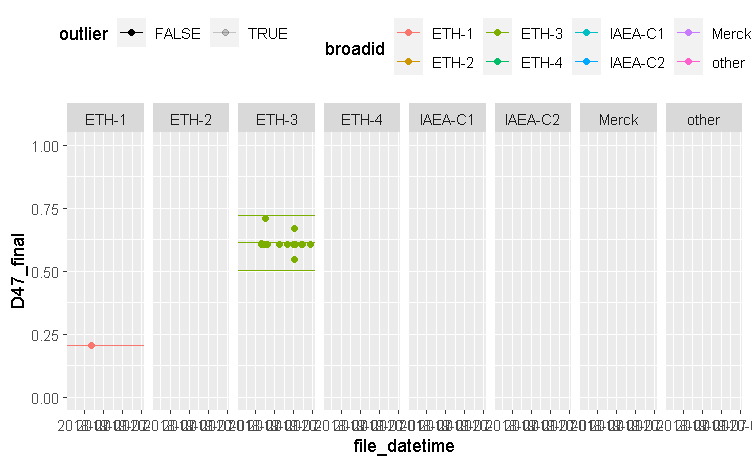

```r
  tar_read(motu_temperature) |>
    filter(etf_grp %in% tar_read(motu_temperature)$etf_grp[[1]]) |> # filter the standards of interest for Robin van der Ploeg
    ggplot(aes(file_id = file_id, Analysis = Analysis,
               x=file_datetime,
               y=D47_final,
               col=broadid,
               label = reason_for_outlier,
               alpha = outlier)) +
    ## geom_pointrange() +
    geom_point() +
    geom_line() +
    geom_hline(aes(yintercept = criteria_min, colour = broadid), data = motu_4sd) +
    geom_hline(aes(yintercept = criteria_max, colour = broadid), data = motu_4sd) +
    geom_hline(aes(yintercept = D47, colour = broadid), data = motu_4sd) +
    sam +
    facet_grid(cols = vars(broadid)) + theme(legend.pos = "top") +
    coord_cartesian(ylim = c(0, 1))
```

**** timeofday

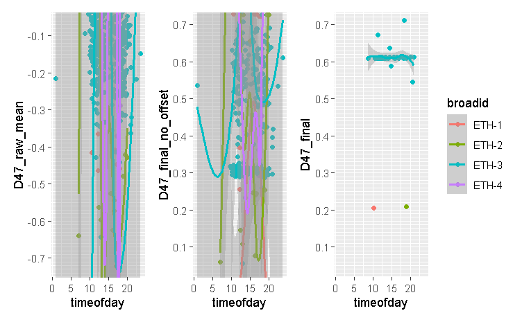

```r
  dat <- tar_read(motu_temperature) |>
    filter(!outlier) |>
    ## filter(broadid == "ETH-3") |>
    ## filter(broadid %in% c("ETH-1", "ETH-2")) |>
    filter(broadid %in% c("ETH-1", "ETH-2", "ETH-3", "ETH-4")) #|>
    ## filter(file_datetime > lubridate::ymd("2020-01-01"))
  Y <- c(.45, .8) # ETH-3
  Y <- c(.1, .3)  # ETH-1 and ETH-2
  Y <- c(.15, .7)  # IAEA-C2
  Y <- c(.05, .7)  # pacman caf

  pl_raw <- dat |>
    ggplot(aes(x=timeofday,
               y = D47_raw_mean,
               ## y = D47_final_no_offset,
               ## y = D47_final,
               colour = broadid)) +
    geom_point() +
    geom_smooth() +
    scale_y_continuous(breaks = seq(-1, 1, .1), minor_breaks = seq(-1, 1, .01)) +
    coord_cartesian(ylim = Y - .77)

  pl_nooff <- dat |>
    ggplot(aes(x=timeofday,
               ## y = D47_raw_mean,
               y = D47_final_no_offset,
               ## y = D47_final,
               colour = broadid)) +
    geom_point() +
    geom_smooth() +
    scale_y_continuous(breaks = seq(-1, 1, .1), minor_breaks = seq(-1, 1, .01)) +
    coord_cartesian(ylim = Y)

  pl_fin <- dat |>
    ggplot(aes(x=timeofday,
               ## y = D47_raw_mean,
               ## y = D47_final_no_offset,
               y = D47_final,
               colour = broadid)) +
    geom_point() +
    geom_smooth() +
    scale_y_continuous(breaks = seq(-1, 1, .1), minor_breaks = seq(-1, 1, .01)) +
    coord_cartesian(ylim = Y)


  pl_raw + pl_nooff + pl_fin + plot_layout(guides = "collect")
```

## D47 STD summary

*** motu

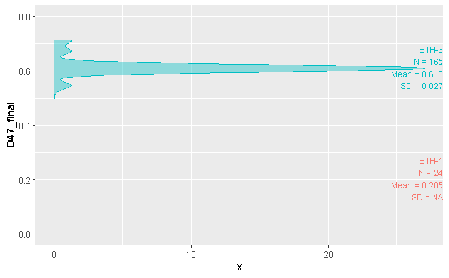

```r
  samp_size <- tar_read(motu_temperature) |>
    filter(!outlier, broadid != "other") |>
    measurement_filter() |>
    group_by(broadid) |>
    summarize(N = n(),
              ymean = mean(D47_final, na.rm = TRUE),
              ysd = sd(D47_final, na.rm = TRUE),
              ymax = max(ymean + mean(D47_raw_cl, na.rm = TRUE) / max(etf_slope_grp), na.rm = TRUE) + .1)
  tar_read(motu_temperature) |>
    measurement_filter() |>
    filter(!outlier, broadid != "other") |>
    ggplot(aes(y=D47_final,
               col=broadid,
               fill=broadid)) +
    geom_density(alpha = .4, ## n = 10000,
                 show.legend=FALSE) +
    ## geom_boxplot(aes(x = 0), position = "identity", alpha = .7, show.legend = F) +
    geom_text(aes(label = paste0(broadid,
                                 "\nN = ", N,
                                 "\nMean = ", round(ymean, 3),
                                 "\nSD = ", round(ysd, 3)),
                  y = ymean,
                  x = Inf),
              size = 3,
              hjust = 1,
              show.legend=F,
              position = "identity", data = samp_size) +
    coord_cartesian(ylim = c(0, .8))
```